# Prediction Assignment Writeup

NicolasGarcesR

9/22/2020

Lets load the data

```r
train <- read.csv(url('https://d396qusza40orc.cloudfront.net/predmachlearn/pml-training.csv'), header= T)
test <- read.csv(url('https://d396qusza40orc.cloudfront.net/predmachlearn/pml-testing.csv'), header = T)
head(train)
```

```
##   X user_name raw_timestamp_part_1 raw_timestamp_part_2   cvtd_timestamp
## 1 1  carlitos           1323084231               788290 05/12/2011 11:23
## 2 2  carlitos           1323084231               808298 05/12/2011 11:23
## 3 3  carlitos           1323084231               820366 05/12/2011 11:23
## 4 4  carlitos           1323084232               120339 05/12/2011 11:23
## 5 5  carlitos           1323084232               196328 05/12/2011 11:23
## 6 6  carlitos           1323084232               304277 05/12/2011 11:23
##   new_window num_window roll_belt pitch_belt yaw_belt total_accel_belt
## 1         no         11      1.41       8.07    -94.4                3
## 2         no         11      1.41       8.07    -94.4                3
## 3         no         11      1.42       8.07    -94.4                3
## 4         no         12      1.48       8.05    -94.4                3
## 5         no         12      1.48       8.07    -94.4                3
## 6         no         12      1.45       8.06    -94.4                3
##   kurtosis_roll_belt kurtosis_picth_belt kurtosis_yaw_belt skewness_roll_belt
```

[output cut: 251 more lines]

Now, we have to fix the missing data and dropping the data that is not usefull

```r
train <- train%>% select_if(colSums(is.na(train)) < 19000)
train<- train[, colSums(is.na(train)) == 0]
test <- test[, colSums(is.na(test))== 0]
train <- train[, -c(1:7)]
test <- test[, -c(1:7)]
```

Now let’s divide in a 70/30 proportion

```r
set.seed(123)
partition <- sample(19622,13735)
real_train<- train[partition,]
train_test <- train[-partition,]
real_train$classe
```

[output not shown]

[output cut: 368 more lines]

let’s explore the variable of interess (classe)

```r
table(train$classe)
```

```
##
##    A    B    C    D    E
## 5580 3797 3422 3216 3607
```

## Regresion tree

lets make a tree

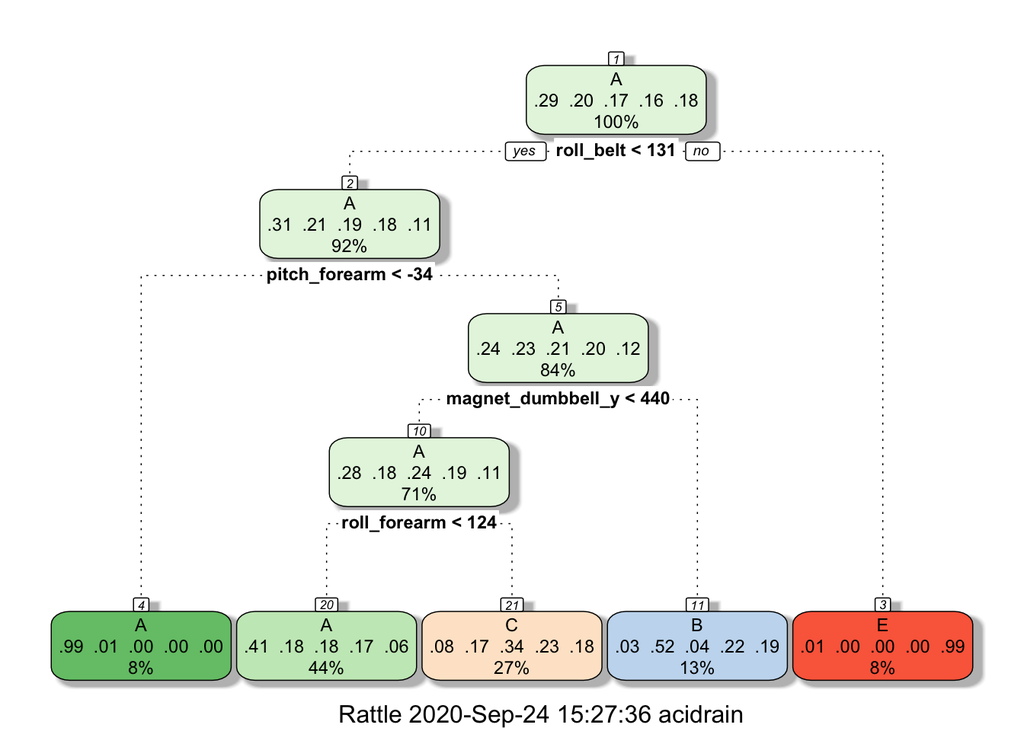

```r
trControl <- trainControl(method="cv", number=5)
tree <- train(classe~., data=real_train, method="rpart", trControl=trControl)
fancyRpartPlot(tree$finalModel)
```

roll_belt, pitch_forearm, magnet_dumbbell and roll forearm are the main elements to divide the activities with the biggest homogeneity possible. However group A is divided in two groups, which means it might have a lot of variance and our estimation might not be the greatest.

```r
pred <- predict(tree,train_test)
cross<- confusionMatrix(train_test$classe,pred)
cross
```

```
## Confusion Matrix and Statistics
##
##           Reference
## Prediction    A    B    C    D    E
##          A 1508   23  127    0    6
##          B  464  355  295    0    0
##          C  512   30  484    0    0
##          D  435  173  367    0    0
##          E  172  146  296    0  494
##
## Overall Statistics
##
##                Accuracy : 0.4826
##                  95% CI : (0.4698, 0.4954)
##     No Information Rate : 0.5251
##     P-Value [Acc > NIR] : 1
##
##                   Kappa : 0.3243
##
##  Mcnemar's Test P-Value : NA
##
## Statistics by Class:
##
##                      Class: A Class: B Class: C Class: D Class: E
## Sensitivity            0.4879   0.4883  0.30848       NA  0.98800
## Specificity            0.9442   0.8529  0.87448   0.8344  0.88602
## Pos Pred Value         0.9062   0.3187  0.47173       NA  0.44585
## Neg Pred Value         0.6251   0.9221  0.77679       NA  0.99874
## Prevalence             0.5251   0.1235  0.26652   0.0000  0.08493
## Detection Rate         0.2562   0.0603  0.08222   0.0000  0.08391
## Detection Prevalence   0.2827   0.1892  0.17428   0.1656  0.18821
## Balanced Accuracy      0.7160   0.6706  0.59148       NA  0.93701
```

The model has a 48% of accuracy, not very good at all. let’s try a different method

## Random Forest

to make it computational feasible, i had to cut the data to run this one.

```r
newsamp<- sample(13735,3000)
pls_train<- real_train[newsamp,]
pls_test <- train_test[-newsamp,]
pls_train<- pls_train[,c(1:4,14:35,42:44,54:66, 76:86)]
pls_test<- pls_test[,c(1:4,14:35,42:44,54:66, 76:86)]
```

```r
controlRF <- trainControl(method="cv", number=3, verboseIter=FALSE)
forest <- train(classe ~ ., data = pls_train,method = "rf", trControl=controlRF )
rf_pred<- predict(forest, newdata = pls_test)
confusionMatrix(rf_pred, pls_test$classe)
```

```
## Confusion Matrix and Statistics
##
##           Reference
## Prediction    A    B    C    D    E
##          A 1277   43    0    2    4
##          B   11  812   18    8    5
##          C    2   27  765   15    1
##          D    6    2   12  736    9
##          E    1    3    0    3  837
##
## Overall Statistics
##
##                Accuracy : 0.9626
##                  95% CI : (0.9567, 0.9679)
##     No Information Rate : 0.282
##     P-Value [Acc > NIR] : < 2.2e-16
##
##                   Kappa : 0.9527
##
##  Mcnemar's Test P-Value : 0.000125
##
## Statistics by Class:
##
##                      Class: A Class: B Class: C Class: D Class: E
## Sensitivity            0.9846   0.9154   0.9623   0.9634   0.9778
## Specificity            0.9852   0.9887   0.9882   0.9924   0.9981
## Pos Pred Value         0.9630   0.9508   0.9444   0.9621   0.9917
## Neg Pred Value         0.9939   0.9800   0.9921   0.9927   0.9949
## Prevalence             0.2820   0.1929   0.1729   0.1661   0.1861
## Detection Rate         0.2777   0.1766   0.1663   0.1600   0.1820
## Detection Prevalence   0.2883   0.1857   0.1761   0.1663   0.1835
## Balanced Accuracy      0.9849   0.9521   0.9752   0.9779   0.9880
```

```r
last_test <- predict(forest,newdata=test)
last_test
```

```
##  [1] B A B A A E D B A A B C B A E E A B B B
## Levels: A B C D E
```